# TP 2 - Estratificacion Mesas Electorales Hogares

Gomez Vargas Andrea, Iummato Luciana, Pesce Andrea Gisele

2024-12-01

# Paquetes de trabajo

```r
library(tidyverse)
library(survey)
library(readxl)
library(gt)
library(sampling)
library(VIM)
library(binom)
library(openxlsx)
library(DT)
library(stratification)
library(kableExtra)
options(scipen = 999)
```

# Ejercicio 1

```r
#Importar datos

marco <- read.csv("data/MESAS_ESCRUTADAS_Cierre.csv", encoding = "UTF-8")
```

```r
#Explorar datos

names(marco)
```

```
##  [1] "Agrupacion"      "Cargo"           "Codigo"          "Distrito"
##  [5] "Establecimiento" "Fecha"           "IdCargo"         "IdCircuito"
##  [9] "IdDistrito"      "IdSeccion"       "Mesa"            "Seccion"
## [13] "electores"       "envio"           "idAgrupacion"    "idAgrupacionInt"
## [17] "tipoVoto"        "votos"
```

```r
glimpse(marco)
```

```
## Rows: 2,665,130
## Columns: 18
## $ Agrupacion      <chr> "", "", "", "", "", "JUNTOS POR EL CAMBIO", "FRENTE DE…
## $ Cargo           <chr> "DIPUTADOS PROVINCIALES", "DIPUTADOS PROVINCIALES", "D…
## $ Codigo          <int> 22, 22, 22, 22, 22, 22, 22, 22, 22, 22, 74, 74, 74, 74…
## $ Distrito        <chr> "Ciudad Autónoma de Buenos Aires", "Ciudad Autónoma de…
## $ Establecimiento <chr> "Colegio Nac. Nº2 D. F. Sarmiento", "Colegio Nac. Nº2 …
## $ Fecha           <chr> "14-11-2021 18:30", "14-11-2021 18:30", "14-11-2021 18…
## $ IdCargo         <int> 6, 6, 6, 6, 6, 6, 6, 6, 6, 6, 6, 6, 6, 6, 6, 6, 6, 6, …
## $ IdCircuito      <chr> "00006", "00006", "00006", "00006", "00006", "00006", …
## $ IdDistrito      <int> 1, 1, 1, 1, 1, 1, 1, 1, 1, 1, 1, 1, 1, 1, 1, 1, 1, 1, …
## $ IdSeccion       <int> 1, 1, 1, 1, 1, 1, 1, 1, 1, 1, 1, 1, 1, 1, 1, 1, 1, 1, …
## $ Mesa            <chr> "09060E", "09060E", "09060E", "09060E", "09060E", "090…
## $ Seccion         <chr> "Comuna 01", "Comuna 01", "Comuna 01", "Comuna 01", "C…
## $ electores       <int> 346, 346, 346, 346, 346, 346, 346, 346, 346, 346, 350,…
## $ envio           <int> 1, 1, 1, 1, 1, 1, 1, 1, 1, 1, 1, 1, 1, 1, 1, 1, 1, 1, …
## $ idAgrupacion    <int> NA, NA, NA, NA, NA, 501, 502, 504, 503, 187, NA, NA, N…
## $ idAgrupacionInt <int> NA, NA, NA, NA, NA, 11, 12, 14, 13, 7, NA, NA, NA, NA,…
## $ tipoVoto        <chr> "blancos", "nulos", "recurridos", "comando", "impugnad…
## $ votos           <int> 0, 1, 0, 0, 0, 9, 6, 3, 2, 0, 1, 0, 0, 0, 0, 29, 13, 1…
```

```r
marco$Agrupacion<-as.factor(marco$Agrupacion)
```

## 1. Qué cantidad mínima de variables identifica una mesa electoral? Y un colegio?

```
a. Mesa electoral: Distrito, sección, circuito, establecimiento y el propio código de la mesa

b. Establecimiento: Distrito, sección, circuito, y el propio nombre del establecimiento
```

## 2. Hallar la proporción de votos a diputados por cada uno de los cuatro agrupamientos de partidos (son 3 segun el enunciado inicial del TP:FdT, JxC y FIT)

```r
#Filtro votos positivos + votos diputados
marco_positivos<-marco %>% filter(tipoVoto=="positivo"& Cargo=="DIPUTADOS NACIONALES")
```

```r
# Elimino algunas variables
marco_positivos$Codigo <- NULL
marco_positivos$Fecha <- NULL
marco_positivos$Cargo <- NULL
marco_positivos$envio <- NULL
marco_positivos$idAgrupacion <- NULL
marco_positivos$idCargo <- NULL
marco_positivos$idAgrupacionInt <- NULL
```

```r
total_votos <- marco_positivos %>%
  summarise(total_votos = sum(votos)) %>%
  pull(total_votos)

total_votos
```

```
## [1] 23238621
```

```r
#Recodificar partidos
marco_positivos$Partido <- "Resto"
marco_positivos$Partido <-
  ifelse(substr(marco_positivos$Agrupacion,1,15)=="FRENTE DE TODOS","FdT",marco_positivos$Partido)
marco_positivos$Partido <-
  ifelse(substr(marco_positivos$Agrupacion,1,19)==
           "FRENTE DE IZQUIERDA","FIT",marco_positivos$Partido)
marco_positivos$Partido <- ifelse(substr(marco_positivos$Agrupacion,1,6)==
                                "JUNTOS","Juntos",marco_positivos$Partido)
```

```r
#proporción de voto a diputados por partidos
proporciones<-marco_positivos %>%
  group_by(Partido) %>%
  summarise(votos_agrupacion= sum(votos),
            proporcion= round(votos_agrupacion/total_votos*100,1)
            )

proporciones
```

| Partido | votos_agrupacion | proporcion |
| --- | --- | --- |
| FIT | 1194947 | 5.1 |
| FdT | 7339755 | 31.6 |
| Juntos | 7973281 | 34.3 |
| Resto | 6730638 | 29.0 |

## 3. Tabular la cantidad de colegios electorales, mesas electorales y electores por Estrato

6 estratos: CABA, Partidos del Gran Buenos Aires, Resto de Buenos Aires, Región Pampeana (Córdoba, Santa Fé, La Pampa, Entre Ríos), NEA - NOA, Resto

```r
#creación variable estratos
table(marco_positivos$Distrito)
```

```
##
##                                          Buenos Aires
##                                                217470
##                                             Catamarca
##                                                  5015
##                                                 Chaco
##                                                 14020
##                                                Chubut
##                                                  6565
##                       Ciudad Autónoma de Buenos Aires
##                                                 36670
##                                               Córdoba
##                                                 62013
##                                            Corrientes
##                                                 10344
##                                            Entre Ríos
##                                                 23373
##                                               Formosa
##                                                  4224
##                                                 Jujuy
##                                                  5112
##                                              La Pampa
##                                                  4400
##                                              La Rioja
##                                                  4585
##                                               Mendoza
##                                                 29344
##                                              Misiones
##                                                 13755
##                                               Neuquén
##                                                 11074
##                                             Río Negro
##                                                 10038
##                                                 Salta
##                                                 21875
##                                              San Juan
##                                                  6860
##                                              San Luis
##                                                  6135
##                                            Santa Cruz
##                                                  4370
##                                              Santa Fe
##                                                 73152
##                                   Santiago del Estero
##                                                 16359
## Tierra del Fuego, Antártida e Islas del Atlántico Sur
##                                                  3409
##                                               Tucumán
##                                                 18770
```

```r
GBA <- c("Avellaneda","Almirante Brown","Berazategui","Esteban Echeverría",
         "Ezeiza","Florencio Varela","General San Martín","Hurlingham","Ituzaingó",
         "José C. Paz","La Matanza","Lanús","Lomas de Zamora",
         "Malvinas Argentinas","Merlo","Moreno","Morón",
         "Quilmes","San Fernando","San Isidro","San Miguel","Tigre","Tres de Febrero","Vicente López")

marco_positivos<-  marco_positivos %>% mutate(estrato =case_when(
  Distrito== "Ciudad Autónoma de Buenos Aires" ~ "CABA",
  Distrito== "Córdoba" | Distrito== "Entre Ríos"| Distrito== "La Pampa"| Distrito== "Santa Fe"  ~ "Región_pampeana",
  Distrito== "Chaco" | Distrito== "Catamarca"| Distrito== "Corrientes"| Distrito== "Formosa"  | Distrito== "Santiago del Estero"  |
  Distrito== "Jujuy" | Distrito== "Misiones"| Distrito== "La Rioja"| Distrito== "Salta"| Distrito== "Tucumán"~ "NEA_NOA",
  Seccion %in% GBA & Distrito== "Buenos Aires"~ "GBA",
  !Seccion %in% GBA & Distrito== "Buenos Aires" ~ "Resto_BsAs",
   TRUE~"Resto_país"))

table(marco_positivos$Distrito,marco_positivos$estrato)
```

```
##
##                                                           CABA    GBA NEA_NOA
##   Buenos Aires                                               0 129474       0
##   Catamarca                                                  0      0    5015
##   Chaco                                                      0      0   14020
##   Chubut                                                     0      0       0
##   Ciudad Autónoma de Buenos Aires                        36670      0       0
##   Córdoba                                                    0      0       0
##   Corrientes                                                 0      0   10344
##   Entre Ríos                                                 0      0       0
##   Formosa                                                    0      0    4224
##   Jujuy                                                      0      0    5112
##   La Pampa                                                   0      0       0
##   La Rioja                                                   0      0    4585
##   Mendoza                                                    0      0       0
##   Misiones                                                   0      0   13755
##   Neuquén                                                    0      0       0
##   Río Negro                                                  0      0       0
##   Salta                                                      0      0   21875
##   San Juan                                                   0      0       0
##   San Luis                                                   0      0       0
##   Santa Cruz                                                 0      0       0
##   Santa Fe                                                   0      0       0
##   Santiago del Estero                                        0      0   16359
##   Tierra del Fuego, Antártida e Islas del Atlántico Sur      0      0       0
##   Tucumán                                                    0      0   18770
##
##                                                         Región_pampeana
##   Buenos Aires                                                        0
##   Catamarca                                                           0
##   Chaco                                                               0
##   Chubut                                                              0
##   Ciudad Autónoma de Buenos Aires                                     0
##   Córdoba                                                         62013
##   Corrientes                                                          0
##   Entre Ríos                                                      23373
##   Formosa                                                             0
##   Jujuy                                                               0
##   La Pampa                                                         4400
##   La Rioja                                                            0
```

[output cut: 23 more lines]

```
##   Jujuy                                                          0          0
##   La Pampa                                                       0          0
##   La Rioja                                                       0          0
##   Mendoza                                                        0      29344
##   Misiones                                                       0          0
##   Neuquén                                                        0      11074
##   Río Negro                                                      0      10038
##   Salta                                                          0          0
##   San Juan                                                       0       6860
##   San Luis                                                       0       6135
##   Santa Cruz                                                     0       4370
##   Santa Fe                                                       0          0
##   Santiago del Estero                                            0          0
##   Tierra del Fuego, Antártida e Islas del Atlántico Sur          0       3409
##   Tucumán                                                        0          0
```

```r
#Creación de tabla de estratos
tabla_estratos0 <-marco_positivos %>%
  group_by(estrato,Distrito,IdSeccion,IdCircuito, Establecimiento,Mesa) %>%
  summarise(electores = first(electores), .groups = "drop")

tabla_estratos1<-tabla_estratos0 %>%
 group_by(estrato,Distrito,IdSeccion,IdCircuito, Establecimiento) %>%
 summarise(mesas= n(),
           electores = sum(electores))

tabla_estratos_final <- tabla_estratos1 %>%
 group_by(estrato) %>%
 summarise(
 Establecimientos = n(),
 TotalMesas = sum(mesas),
 TotalElectores = sum(electores)
   )


tabla_estratos_final
```

| estrato | Establecimientos | TotalMesas | TotalElectores |
| --- | --- | --- | --- |
| CABA | 1021 | 7334 | 2535912 |
| GBA | 3270 | 21579 | 7547222 |
| NEA_NOA | 3832 | 22389 | 7503865 |
| Región_pampeana | 3757 | 21206 | 7137693 |
| Resto_BsAs | 2840 | 14666 | 4983390 |
| Resto_país | 2222 | 13063 | 4318698 |

## 4. Construir a partir del archivo dado una tabla de mesas electorales (lo necesitaremos más adelante),cada una con el total de votos a cada partido, el total de votos positivos y las variables de identificación.

```r
tabla_votos_mesa <-marco_positivos %>%
  group_by(estrato,Distrito, IdSeccion,IdCircuito, Establecimiento,Mesa,Partido) %>%
  summarise(Voto = sum(votos,na.rm = TRUE))%>%
  pivot_wider(names_from = Partido,
              values_from = Voto)%>%
  mutate(
    # Reemplaza NAs por 0 en las columnas de votos
    FdT = if_else(is.na(FdT), 0, FdT),
    Juntos = if_else(is.na(Juntos), 0, Juntos),
    FIT = if_else(is.na(FIT), 0, FIT),
    Resto = if_else(is.na(Resto), 0, Resto),
    # Calcula el total con los valores de votos
    Total = FdT + Juntos + FIT + Resto
  ) %>%
  ungroup()

head(tabla_votos_mesa) # mostramos los primeros 10 resultados
```

| estrato | Distrito | IdSeccion | IdCircuito | Establecimiento | Mesa | FIT | FdT | Juntos | Resto | Total |
| --- | --- | --- | --- | --- | --- | --- | --- | --- | --- | --- |
| CABA | Ciudad Autónoma de Buenos Aires | 1 | 00001 | CENOF Centro Isauro Arancibia | 00025X | 22 | 76 | 79 | 49 | 226 |
| CABA | Ciudad Autónoma de Buenos Aires | 1 | 00001 | CENOF Centro Isauro Arancibia | 00026X | 20 | 72 | 93 | 48 | 233 |
| CABA | Ciudad Autónoma de Buenos Aires | 1 | 00001 | CENOF Centro Isauro Arancibia | 00027X | 26 | 70 | 80 | 55 | 231 |
| CABA | Ciudad Autónoma de Buenos Aires | 1 | 00001 | Esc. Integral Interdisciplinaria Nº3 | 00019X | 28 | 81 | 69 | 49 | 227 |
| CABA | Ciudad Autónoma de Buenos Aires | 1 | 00001 | Esc. Integral Interdisciplinaria Nº3 | 00020X | 25 | 70 | 98 | 44 | 237 |
| CABA | Ciudad Autónoma de Buenos Aires | 1 | 00001 | Esc. Integral Interdisciplinaria Nº3 | 00021X | 23 | 82 | 94 | 34 | 233 |

## 5. A partir de la tabla de mesas electorales construir la tabla de colegios electorales, cada uno con el total de votos a cada partido, el total de votos positivos y las variables de identificación.

```r
tabla_votos_establecimiento <-marco_positivos %>%
  group_by(estrato,Distrito, IdSeccion,IdCircuito, Establecimiento,Partido) %>%
  summarise(Voto = sum(votos,na.rm = TRUE))%>%
  pivot_wider(names_from = Partido,
              values_from = Voto)%>%
  mutate(
    # Reemplaza NAs por 0 en las columnas de votos
    FdT = if_else(is.na(FdT), 0, FdT),
    Juntos = if_else(is.na(Juntos), 0, Juntos),
    FIT = if_else(is.na(FIT), 0, FIT),
    Resto = if_else(is.na(Resto), 0, Resto),
    # Calcula el total con los valores de votos
    Total = FdT + Juntos + FIT + Resto
  ) %>%
  ungroup()

head(tabla_votos_establecimiento)
```

| estrato | Distrito | IdSeccion | IdCircuito | Establecimiento | FIT | FdT | Juntos | Resto | Total |
| --- | --- | --- | --- | --- | --- | --- | --- | --- | --- |
| CABA | Ciudad Autónoma de Buenos Aires | 1 | 00001 | CENOF Centro Isauro Arancibia | 68 | 218 | 252 | 152 | 690 |
| CABA | Ciudad Autónoma de Buenos Aires | 1 | 00001 | Esc. Integral Interdisciplinaria Nº3 | 76 | 233 | 261 | 127 | 697 |
| CABA | Ciudad Autónoma de Buenos Aires | 1 | 00001 | Esc. N°4 Baldomero Fernandez | 65 | 227 | 265 | 154 | 711 |
| CABA | Ciudad Autónoma de Buenos Aires | 1 | 00001 | Esc. Nº26 Hipólito Yrigoyen | 212 | 717 | 807 | 386 | 2122 |
| CABA | Ciudad Autónoma de Buenos Aires | 1 | 00001 | Esc. Nº27 Dean Funes | 80 | 229 | 274 | 153 | 736 |
| CABA | Ciudad Autónoma de Buenos Aires | 1 | 00001 | Esc. Nº3 Bernardino Rivadavia | 57 | 235 | 274 | 156 | 722 |

## 6. Tabular y graficar los tres totales y los tres porcentajes poblacionales a estimar

```r
#Tabla
totales <- tabla_votos_establecimiento %>%
  summarise(
    Total_FdT = sum(FdT,na.rm = TRUE),
    Total_Juntos = sum(Juntos,na.rm = TRUE),
    Total_FIT = sum(FIT,na.rm = TRUE),
    Total_Resto = sum(Resto,na.rm = TRUE),
    Total_votos = sum(Total,na.rm = TRUE),
    Porcentaje_FdT = round(Total_FdT/Total_votos*100,2),
    Porcentaje_Juntos = round(Total_Juntos/Total_votos*100,2),
    Porcentaje_FIT = round(Total_FIT/Total_votos*100,2),
    Porcentaje_Resto = round(Total_Resto/Total_votos*100,2)
  )

totales
```

| Total_FdT | Total_Juntos | Total_FIT | Total_Resto | Total_votos | Porcentaje_FdT | Porcentaje_Juntos | Porcentaje_FIT | Porcentaje_Resto |
| --- | --- | --- | --- | --- | --- | --- | --- | --- |
| 7339755 | 7973281 | 1194947 | 6730638 | 23238621 | 31.58 | 34.31 | 5.14 | 28.96 |

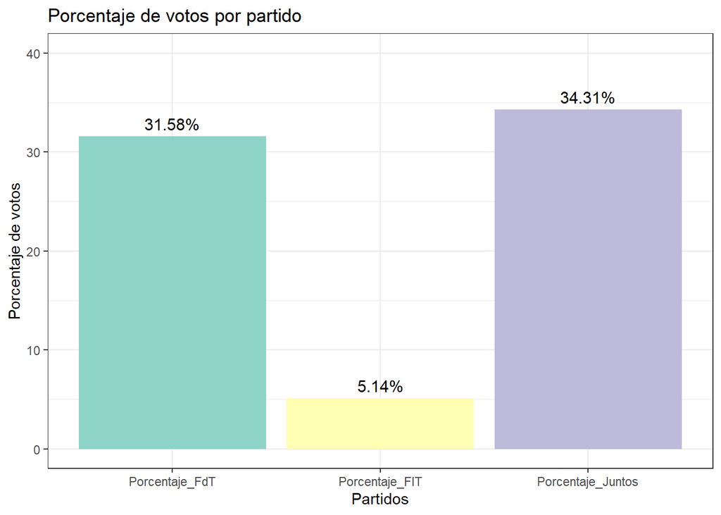

```r
#Gráfico
totales_long <- totales %>%
  select(Porcentaje_FdT, Porcentaje_FIT, Porcentaje_Juntos) %>%
  pivot_longer(cols = everything(), names_to = "Partido", values_to = "Porcentaje")

# Limpiar los nombres de los partidos
totales_long$Partido <- gsub("_Porcentaje", "", totales_long$Partido)

ggplot(totales_long, aes(x = Partido, y = Porcentaje, fill = Partido)) +
  geom_col() + # Gráfico de barras
  geom_text(aes(label = paste0(Porcentaje, "%")),  # Agregar etiquetas con porcentajes
            vjust = -0.5, size = 4) +              # Ajustar posición y tamaño del texto
  ylim(c(0,40)) +
  labs(
    title = "Porcentaje de votos por partido",
    x = "Partidos",
    y = "Porcentaje de votos"
  ) +
  theme_bw() +
  scale_fill_brewer(palette = "Set3") + # Escala de colores agradable
  theme(legend.position = "none")
```

## 7. Seleccionar con sampling una muestra de colegios con cada estrategia

### Estrategia 1 con MAS

```r
# Cantidad de estratos
H=6
#tamaño muestra establecimientos
n=400
#tamaño universo establecimientos
N=sum(tabla_estratos_final$Establecimientos)
```

```r
#Creo variables para ponderar la muestra en mi marco
tabla_estratos_final<-tabla_estratos_final %>%
  mutate(pesos=Establecimientos/N,
         n_prop= round(n*TotalElectores/sum(TotalElectores)))
# Control
sum(tabla_estratos_final$n_prop)
```

```
## [1] 401
```

```r
#Agrego fpc a marco muestral (establecimientos por estrato?)
tabla_votos_establecimiento <-  tabla_votos_establecimiento %>%
  group_by(estrato) %>%
  mutate(fpc=n())
```

```r
#Ordeno el marco de muestreo por estrato (lo pide sampling)
tabla_votos_establecimiento <-  tabla_votos_establecimiento[order(tabla_votos_establecimiento$estrato),]
```

```r
#Selección de muestra
smplMAS = sampling::strata(tabla_votos_establecimiento, stratanames = c("estrato") ,
                             size=tabla_estratos_final$n_prop , description=TRUE,
                             method = "srswor")
```

```
## Stratum 1
##
## Population total and number of selected units: 1021 30
## Stratum 2
##
## Population total and number of selected units: 3270 89
## Stratum 3
##
## Population total and number of selected units: 3832 88
## Stratum 4
##
## Population total and number of selected units: 3757 84
## Stratum 5
##
## Population total and number of selected units: 2840 59
## Stratum 6
##
## Population total and number of selected units: 2222 51
## Number of strata  6
## Total number of selected units 401
```

```r
# Recupero datos del marco de muestreo
muestra_casos <- sampling::getdata(tabla_votos_establecimiento,smplMAS)
```

```r
# Calculo el factor de expansion utilizando probabilidad de seleccion calculada
muestra_casos$pondera <- 1/muestra_casos$Prob
```

## 8. Calcular con survey las estimaciones pedidas, junto a sus CV, IC(90%) y deff.

```r
# Le indico a survey el diseno de muestra
# Indico fpc por estrato
diseno <- survey::svydesign(id=~1, strata = ~estrato,
                              weights = ~pondera,  data=muestra_casos,
                              fpc = ~fpc)
diseno
```

```
## Stratified Independent Sampling design
## survey::svydesign(id = ~1, strata = ~estrato, weights = ~pondera,
##     data = muestra_casos, fpc = ~fpc)
```

```r
#Estimaciones de totales
# FdT
EstimTotalFdT <- survey::svytotal(~FdT, diseno, deff=TRUE, cv=TRUE )
EstimTotalFdT
```

```
##       total      SE  DEff
## FdT 6780654  256756 0.884
```

```r
cv(EstimTotalFdT)
```

```
##          FdT
## FdT 0.037866
```

```r
deff(EstimTotalFdT)
```

```
##       FdT
## 0.8840245
```

```r
confint(EstimTotalFdT)
```

```
##       2.5 %  97.5 %
## FdT 6277421 7283887
```

```r
# FIT
EstimTotalFIT <- survey::svytotal(~FIT, diseno, deff=TRUE, cv=TRUE )
EstimTotalFIT
```

```
##       total      SE   DEff
## FIT 1207853   63234 0.8569
```

```r
cv(EstimTotalFIT)
```

```
##            FIT
## FIT 0.05235264
```

```r
deff(EstimTotalFIT)
```

```
##       FIT
## 0.8569498
```

```r
confint(EstimTotalFdT)
```

```
##       2.5 %  97.5 %
## FdT 6277421 7283887
```

```r
# Juntos
EstimTotalJuntos <- survey::svytotal(~Juntos, diseno, deff=TRUE, cv=TRUE )
EstimTotalJuntos
```

```
##          total      SE   DEff
## Juntos 7427556  289942 0.7136
```

```r
cv(EstimTotalJuntos)
```

```
##            Juntos
## Juntos 0.03903594
```

```r
deff(EstimTotalJuntos)
```

```
##    Juntos
## 0.7135636
```

```r
confint(EstimTotalFdT)
```

```
##       2.5 %  97.5 %
## FdT 6277421 7283887
```

```r
#Dataframe de totales
#FdT
# Extraer el total y el error estándar
total <- coef(EstimTotalFdT)  # Estimación del total
se <- SE(EstimTotalFdT)       # Error estándar

# Extraer coeficiente de variación y diseño efectivo
cv_val <- cv(EstimTotalFdT)   # Coeficiente de variación
deff_val <- deff(EstimTotalFdT)  # Diseño efectivo

# Extraer el intervalo de confianza
conf <- confint(EstimTotalFdT)  # Intervalo de confianza

# Crear un data.frame con los resultados
resultados_totalesFdT <- data.frame(
  Total = total,
  SE = se,
  CV = cv_val,
  Deff = deff_val,
  IC_Lower = conf[, 1],  # Límite inferior del intervalo de confianza
  IC_Upper = conf[, 2]   # Límite superior del intervalo de confianza
)

#FIT
# Extraer el total y el error estándar
total <- coef(EstimTotalFIT)  # Estimación del total
se <- SE(EstimTotalFIT)       # Error estándar

# Extraer coeficiente de variación y diseño efectivo
cv_val <- cv(EstimTotalFIT)   # Coeficiente de variación
deff_val <- deff(EstimTotalFIT)  # Diseño efectivo

# Extraer el intervalo de confianza
conf <- confint(EstimTotalFIT)  # Intervalo de confianza

# Crear un data.frame con los resultados
resultados_totalesFIT <- data.frame(
  Total = total,
  SE = se,
  CV = cv_val,
  Deff = deff_val,
  IC_Lower = conf[, 1],  # Límite inferior del intervalo de confianza
  IC_Upper = conf[, 2]   # Límite superior del intervalo de confianza
)

#Juntos
# Extraer el total y el error estándar
total <- coef(EstimTotalJuntos)  # Estimación del total
se <- SE(EstimTotalJuntos)       # Error estándar

# Extraer coeficiente de variación y diseño efectivo
cv_val <- cv(EstimTotalJuntos)   # Coeficiente de variación
deff_val <- deff(EstimTotalJuntos)  # Diseño efectivo

# Extraer el intervalo de confianza
conf <- confint(EstimTotalJuntos)  # Intervalo de confianza

# Crear un data.frame con los resultados
resultados_totalesJuntos <- data.frame(
  Total = total,
  SE = se,
  CV = cv_val,
  Deff = deff_val,
  IC_Lower = conf[, 1],  # Límite inferior del intervalo de confianza
  IC_Upper = conf[, 2]
)

#Renombrar columnas

colnames(resultados_totalesFdT) <- c(
  "Total",
  "Error Estándar (SE)",
  "Coeficiente de Variación (CV)",
  "Diseño Efectivo (Deff)",
  "IC Inferior",
  "IC Superior"
)
# Ver los resultados
resultados_totalesFdT
```

|  | Total | Error Estándar (SE) | Coeficiente de Variación (CV) | Diseño Efectivo (Deff) | IC Inferior | IC Superior |
| --- | --- | --- | --- | --- | --- | --- |
| FdT | 6780654 | 256756.2 | 0.037866 | 0.8840245 | 6277421 | 7283887 |

```r
colnames(resultados_totalesFIT) <- c(
  "Total",
  "Error Estándar (SE)",
  "Coeficiente de Variación (CV)",
  "Diseño Efectivo (Deff)",
  "IC Inferior",
  "IC Superior"
)
# Ver los resultados
resultados_totalesFIT
```

|  | Total | Error Estándar (SE) | Coeficiente de Variación (CV) | Diseño Efectivo (Deff) | IC Inferior | IC Superior |
| --- | --- | --- | --- | --- | --- | --- |
| FIT | 1207852 | 63234.27 | 0.0523526 | 0.8569498 | 1083916 | 1331789 |

```r
colnames(resultados_totalesJuntos) <- c(
  "Total",
  "Error Estándar (SE)",
  "Coeficiente de Variación (CV)",
  "Diseño Efectivo (Deff)",
  "IC Inferior",
  "IC Superior"
)
# Ver los resultados

resultados_totalesJuntos
```

|  | Total | Error Estándar (SE) | Coeficiente de Variación (CV) | Diseño Efectivo (Deff) | IC Inferior | IC Superior |
| --- | --- | --- | --- | --- | --- | --- |
| Juntos | 7427556 | 289941.6 | 0.0390359 | 0.7135636 | 6859281 | 7995831 |

```r
#Estimaciones de proporciones
# FdT
Proporcion_FdT <- survey::svyratio(~FdT , ~Total, diseno, deff=TRUE )
Proporcion_FdT
```

```
## Ratio estimator: svyratio.survey.design2(~FdT, ~Total, diseno, deff = TRUE)
## Ratios=
##        Total
## FdT 0.303833
## SEs=
##           Total
## FdT 0.008072175
```

```r
df_ratio_FdT <- data.frame(Proporcion_FdT[[1]])
df_SE_FdT    <- data.frame( sqrt(Proporcion_FdT[[2]]))
CV_FdT       <- survey::cv(Proporcion_FdT)
df_IC_FdT    <-data.frame(confint(Proporcion_FdT))

df_proporcion_FdT <- cbind(df_ratio_FdT, df_SE_FdT,df_IC_FdT)

df_proporcion_FdT$CV  <- 100*CV_FdT[1,1]
df_proporcion_FdT$deff  <- survey::deff(Proporcion_FdT)
colnames(df_proporcion_FdT) <- c("Proporción", "Error Estándar (SE)", "IC Inferior", "IC Superior", "Coeficiente de Variación (CV)", "Diseño Efectivo (Deff)")

df_proporcion_FdT
```

|  | Proporción | Error Estándar (SE) | IC Inferior | IC Superior | Coeficiente de Variación (CV) | Diseño Efectivo (Deff) |
| --- | --- | --- | --- | --- | --- | --- |
| FdT | 0.303833 | 0.0080722 | 0.2880118 | 0.3196542 | 2.65678 | 0.8629504 |

```r
# FIT
Proporcion_FIT <- survey :: svyratio(~FIT , ~Total, diseno, deff=TRUE )
Proporcion_FIT
```

```
## Ratio estimator: svyratio.survey.design2(~FIT, ~Total, diseno, deff = TRUE)
## Ratios=
##          Total
## FIT 0.05412242
## SEs=
##           Total
## FIT 0.002492794
```

```r
df_ratio_FIT <- data.frame(Proporcion_FIT[[1]])
df_SE_FIT    <- data.frame( sqrt(Proporcion_FIT[[2]]))
CV_FIT       <- survey::cv(Proporcion_FIT)
df_IC_FIT    <-data.frame(confint(Proporcion_FIT))

df_proporcion_FIT <- cbind(df_ratio_FIT, df_SE_FIT,df_IC_FIT)

df_proporcion_FIT$CV  <- 100*CV_FIT[1,1]
df_proporcion_FIT$deff  <- survey::deff(Proporcion_FIT)
colnames(df_proporcion_FIT) <- c("Proporción", "Error Estándar (SE)", "IC Inferior", "IC Superior", "Coeficiente de Variación (CV)", "Diseño Efectivo (Deff)")

df_proporcion_FIT
```

|  | Proporción | Error Estándar (SE) | IC Inferior | IC Superior | Coeficiente de Variación (CV) | Diseño Efectivo (Deff) |
| --- | --- | --- | --- | --- | --- | --- |
| FIT | 0.0541224 | 0.0024928 | 0.0492366 | 0.0590082 | 4.605844 | 0.9032863 |

```r
# Juntos
Proporcion_Juntos <- survey :: svyratio(~Juntos , ~Total, diseno, deff=TRUE )
Proporcion_Juntos
```

```
## Ratio estimator: svyratio.survey.design2(~Juntos, ~Total, diseno, deff = TRUE)
## Ratios=
##            Total
## Juntos 0.3328199
## SEs=
##              Total
## Juntos 0.009618112
```

```r
df_ratio_Juntos <- data.frame(Proporcion_Juntos[[1]])
df_SE_Juntos    <- data.frame( sqrt(Proporcion_Juntos[[2]]))
CV_Juntos       <- survey::cv(Proporcion_Juntos)
df_IC_Juntos    <-data.frame(confint(Proporcion_Juntos))

df_proporcion_Juntos <- cbind(df_ratio_Juntos, df_SE_Juntos,df_IC_Juntos)

df_proporcion_Juntos$CV  <- 100*CV_Juntos[1,1]
df_proporcion_Juntos$deff  <- survey::deff(Proporcion_Juntos)
colnames(df_proporcion_Juntos) <- c("Proporción", "Error Estándar (SE)", "IC Inferior", "IC Superior", "Coeficiente de Variación (CV)", "Diseño Efectivo (Deff)")

df_proporcion_Juntos
```

|  | Proporción | Error Estándar (SE) | IC Inferior | IC Superior | Coeficiente de Variación (CV) | Diseño Efectivo (Deff) |
| --- | --- | --- | --- | --- | --- | --- |
| Juntos | 0.3328199 | 0.0096181 | 0.3139687 | 0.351671 | 2.889885 | 0.6081792 |

### Estrategia 2: Madow en cada estrato, con probabilidad de selección proporcional a la cantidad de mesas electorales del colegio, ordenando los estratos por jurisdicción, Sección y IdCircuito.

```r
#Datos para generar probabilidad de selección
N_mesas<- tabla_votos_mesa %>% group_by(estrato,Distrito, IdSeccion,IdCircuito,Establecimiento) %>%
 summarise(N_mesas = n())

tabla_votos_establecimiento<-tabla_votos_establecimiento %>%
  left_join(N_mesas, by = c("estrato", "Distrito","IdSeccion","IdCircuito", "Establecimiento"))

tabla_votos_establecimiento<-merge(tabla_votos_establecimiento, tabla_estratos_final[, c("estrato", "n_prop", "TotalMesas")],by="estrato")

# Genero probabilidad de seleccion de cada establecimiento
tabla_votos_establecimiento$pi_i <- tabla_votos_establecimiento$n_prop*
  tabla_votos_establecimiento$N_mesas/tabla_votos_establecimiento$TotalMesas

# Controlo
sum(tabla_votos_establecimiento$pi_i)
```

```
## [1] 401
```

```r
# Ordenamos el marco de muestreo

tabla_votos_establecimiento <- tabla_votos_establecimiento[order(tabla_votos_establecimiento$estrato,
                                                                 tabla_votos_establecimiento$Distrito,
                                                                 tabla_votos_establecimiento$IdSeccion,
                                                                 tabla_votos_establecimiento$IdCircuito),]
```

```r
# Selecciono la muestra
smplMadow = sampling::strata(tabla_votos_establecimiento, stratanames = c("estrato") ,
                              size=tabla_estratos_final$n_prop , description=TRUE,
                              method = "systematic", pik=tabla_votos_establecimiento$pi_i)
```

```
## Stratum 1
##
## Population total and number of selected units: 1021 30
## Stratum 2
##
## Population total and number of selected units: 3270 89
## Stratum 3
##
## Population total and number of selected units: 3832 88
## Stratum 4
##
## Population total and number of selected units: 3757 84
## Stratum 5
##
## Population total and number of selected units: 2840 59
## Stratum 6
##
## Population total and number of selected units: 2222 51
## Number of strata  6
## Total number of selected units 401
```

```r
# Recupero datos del marco de muestreo
muestra_2 <- sampling :: getdata(tabla_votos_establecimiento,smplMadow)
```

```r
# Calculo el factor de expansion utilizando probabilidad de seleccion calculada
muestra_2$pondera <- 1/muestra_2$Prob
```

```r
# Le indico a survey el diseno de muestra
# pero supongo muestreo con reposicion (omito fpc)
diseno2 <- survey :: svydesign(id=~1, strata=~estrato,
                              weights=~pondera,  data=muestra_2)
diseno2
```

```
## Stratified Independent Sampling design (with replacement)
## survey::svydesign(id = ~1, strata = ~estrato, weights = ~pondera,
##     data = muestra_2)
```

```r
#Estimaciones de totales
# FdT
EstimTotalFdT2 <- survey :: svytotal(~FdT, diseno2, deff=TRUE, cv=TRUE )
EstimTotalFdT2
```

```
##       total      SE   DEff
## FdT 7385231  168393 0.3887
```

```r
cv(EstimTotalFdT2)
```

```
##            FdT
## FdT 0.02280135
```

```r
deff(EstimTotalFdT2)
```

```
##       FdT
## 0.3887411
```

```r
confint(EstimTotalFdT2)
```

```
##       2.5 %  97.5 %
## FdT 7055186 7715275
```

```r
# FIT
EstimTotalFIT2 <- survey :: svytotal(~FIT, diseno2, deff=TRUE, cv=TRUE )
EstimTotalFIT2
```

```
##       total      SE   DEff
## FIT 1203001   43955 0.4985
```

```r
cv(EstimTotalFIT2)
```

```
##          FIT
## FIT 0.036538
```

```r
deff(EstimTotalFIT2)
```

```
##       FIT
## 0.4984505
```

```r
confint(EstimTotalFIT2)
```

```
##       2.5 %  97.5 %
## FIT 1116850 1289152
```

```r
# Juntos
EstimTotalJuntos2 <- survey :: svytotal(~Juntos, diseno2, deff=TRUE, cv=TRUE )
EstimTotalJuntos2
```

```
##          total      SE   DEff
## Juntos 7958371  199478 0.3357
```

```r
cv(EstimTotalJuntos2)
```

```
##           Juntos
## Juntos 0.0250652
```

```r
deff(EstimTotalJuntos2)
```

```
##    Juntos
## 0.3357305
```

```r
confint(EstimTotalJuntos2)
```

```
##          2.5 %  97.5 %
## Juntos 7567401 8349341
```

```r
#Dataframe de totales
#FdT
# Extraer el total y el error estándar
total <- coef(EstimTotalFdT2)  # Estimación del total
se <- SE(EstimTotalFdT2)       # Error estándar

# Extraer coeficiente de variación y diseño efectivo
cv_val <- cv(EstimTotalFdT2)   # Coeficiente de variación
deff_val <- deff(EstimTotalFdT2)  # Diseño efectivo

# Extraer el intervalo de confianza
conf <- confint(EstimTotalFdT2)  # Intervalo de confianza

# Crear un data.frame con los resultados
resultados_totalesFdT2 <- data.frame(
  Total = total,
  SE = se,
  CV = cv_val,
  Deff = deff_val,
  IC_Lower = conf[, 1],  # Límite inferior del intervalo de confianza
  IC_Upper = conf[, 2]   # Límite superior del intervalo de confianza
)

#FIT
# Extraer el total y el error estándar
total <- coef(EstimTotalFIT2)  # Estimación del total
se <- SE(EstimTotalFIT2)       # Error estándar

# Extraer coeficiente de variación y diseño efectivo
cv_val <- cv(EstimTotalFIT2)   # Coeficiente de variación
deff_val <- deff(EstimTotalFIT2)  # Diseño efectivo

# Extraer el intervalo de confianza
conf <- confint(EstimTotalFIT2)  # Intervalo de confianza

# Crear un data.frame con los resultados
resultados_totalesFIT2 <- data.frame(
  Total = total,
  SE = se,
  CV = cv_val,
  Deff = deff_val,
  IC_Lower = conf[, 1],  # Límite inferior del intervalo de confianza
  IC_Upper = conf[, 2]   # Límite superior del intervalo de confianza
)

#Juntos
# Extraer el total y el error estándar
total <- coef(EstimTotalJuntos2)  # Estimación del total
se <- SE(EstimTotalJuntos2)       # Error estándar

# Extraer coeficiente de variación y diseño efectivo
cv_val <- cv(EstimTotalJuntos2)   # Coeficiente de variación
deff_val <- deff(EstimTotalJuntos2)  # Diseño efectivo

# Extraer el intervalo de confianza
conf <- confint(EstimTotalJuntos2)  # Intervalo de confianza

# Crear un data.frame con los resultados
resultados_totalesJuntos2 <- data.frame(
  Total = total,
  SE = se,
  CV = cv_val,
  Deff = deff_val,
  IC_Lower = conf[, 1],  # Límite inferior del intervalo de confianza
  IC_Upper = conf[, 2]   # Límite superior del intervalo de confianza
)


#Renombrar columnas

colnames(resultados_totalesFdT2) <- c(
  "Total",
  "Error Estándar (SE)",
  "Coeficiente de Variación (CV)",
  "Diseño Efectivo (Deff)",
  "IC Inferior",
  "IC Superior"
)
# Ver los resultados
print(resultados_totalesFdT2)
```

```
##       Total Error Estándar (SE) Coeficiente de Variación (CV)
## FdT 7385231            168393.2                    0.02280135
##     Diseño Efectivo (Deff) IC Inferior IC Superior
## FdT              0.3887411     7055186     7715275
```

```r
colnames(resultados_totalesFIT2) <- c(
  "Total",
  "Error Estándar (SE)",
  "Coeficiente de Variación (CV)",
  "Diseño Efectivo (Deff)",
  "IC Inferior",
  "IC Superior"
)
# Ver los resultados
print(resultados_totalesFIT2)
```

```
##       Total Error Estándar (SE) Coeficiente de Variación (CV)
## FIT 1203001            43955.24                      0.036538
##     Diseño Efectivo (Deff) IC Inferior IC Superior
## FIT              0.4984505     1116850     1289152
```

```r
colnames(resultados_totalesJuntos2) <- c(
  "Total",
  "Error Estándar (SE)",
  "Coeficiente de Variación (CV)",
  "Diseño Efectivo (Deff)",
  "IC Inferior",
  "IC Superior"
)
# Ver los resultados
kable(resultados_totalesJuntos2)
```

|  | Total | Error Estándar (SE) | Coeficiente de Variación (CV) | Diseño Efectivo (Deff) | IC Inferior | IC Superior |
| --- | --- | --- | --- | --- | --- | --- |
| Juntos | 7958371 | 199478.1 | 0.0250652 | 0.3357305 | 7567401 | 8349341 |

```r
#Estimaciones de proporciones
# FdT
Proporcion_FdT2 <- survey :: svyratio(~FdT , ~Total, diseno2, deff=TRUE )
Proporcion_FdT2
```

```
## Ratio estimator: svyratio.survey.design2(~FdT, ~Total, diseno2, deff = TRUE)
## Ratios=
##         Total
## FdT 0.3170756
## SEs=
##           Total
## FdT 0.006937317
```

```r
df_ratio_FdT2 <- data.frame(Proporcion_FdT2[[1]])
df_SE_FdT2    <- data.frame( sqrt(Proporcion_FdT2[[2]]))
CV_FdT2     <- survey::cv(Proporcion_FdT2)
df_IC_FdT2    <-data.frame(confint(Proporcion_FdT2))

df_proporcion_FdT2 <- cbind(df_ratio_FdT2, df_SE_FdT2,df_IC_FdT2)

df_proporcion_FdT2$CV_FdT2  <- 100*CV_FdT2[1,1]
df_proporcion_FdT2$deff  <- survey::deff(Proporcion_FdT2)
colnames(df_proporcion_FdT2) <- c("Proporción", "Error Estándar (SE)", "IC Inferior", "IC Superior", "Coeficiente de Variación (CV)", "Diseño Efectivo (Deff)")

print(df_proporcion_FdT2)
```

```
##     Proporción Error Estándar (SE) IC Inferior IC Superior
## FdT  0.3170756         0.006937317   0.3034787   0.3306725
##     Coeficiente de Variación (CV) Diseño Efectivo (Deff)
## FdT                      2.187906               0.678604
```

```r
# FIT
Proporcion_FIT2 <- survey :: svyratio(~FIT , ~Total, diseno2, deff=TRUE )
Proporcion_FIT2
```

```
## Ratio estimator: svyratio.survey.design2(~FIT, ~Total, diseno2, deff = TRUE)
## Ratios=
##          Total
## FIT 0.05164933
## SEs=
##           Total
## FIT 0.001851705
```

```r
df_ratio_FIT2 <- data.frame(Proporcion_FIT2[[1]])
df_SE_FIT2    <- data.frame( sqrt(Proporcion_FIT2[[2]]))
CV_FIT2       <- survey::cv(Proporcion_FIT2)
df_IC_FIT2    <-data.frame(confint(Proporcion_FIT2))

df_proporcion_FIT2 <- cbind(df_ratio_FIT2, df_SE_FIT2,df_IC_FIT2)

df_proporcion_FIT2$CV  <- 100*CV_FIT2[1,1]
df_proporcion_FIT2$deff  <- survey::deff(Proporcion_FIT2)
colnames(df_proporcion_FIT2) <- c("Proporción", "Error Estándar (SE)", "IC Inferior", "IC Superior", "Coeficiente de Variación (CV)", "Diseño Efectivo (Deff)")

print(df_proporcion_FIT2)
```

```
##     Proporción Error Estándar (SE) IC Inferior IC Superior
## FIT 0.05164933         0.001851705  0.04802006  0.05527861
##     Coeficiente de Variación (CV) Diseño Efectivo (Deff)
## FIT                      3.585147               0.690487
```

```r
# Juntos
Proporcion_Juntos2 <- survey :: svyratio(~Juntos , ~Total, diseno2, deff=TRUE )
Proporcion_Juntos2
```

```
## Ratio estimator: svyratio.survey.design2(~Juntos, ~Total, diseno2, deff = TRUE)
## Ratios=
##            Total
## Juntos 0.3416827
## SEs=
##              Total
## Juntos 0.007938694
```

```r
df_ratio_Juntos2 <- data.frame(Proporcion_Juntos2[[1]])
df_SE_Juntos2    <- data.frame( sqrt(Proporcion_Juntos2[[2]]))
CV_Juntos2       <- survey::cv(Proporcion_Juntos2)
df_IC_Juntos2    <-data.frame(confint(Proporcion_Juntos2))

df_proporcion_Juntos2 <- cbind(df_ratio_Juntos2, df_SE_Juntos2,df_IC_Juntos2)

df_proporcion_Juntos2$CV  <- 100*CV_Juntos2[1,1]
df_proporcion_Juntos2$deff  <- survey::deff(Proporcion_Juntos2)
colnames(df_proporcion_Juntos2) <- c("Proporción", "Error Estándar (SE)", "IC Inferior", "IC Superior", "Coeficiente de Variación (CV)", "Diseño Efectivo (Deff)")

print(df_proporcion_Juntos2)
```

```
##        Proporción Error Estándar (SE) IC Inferior IC Superior
## Juntos  0.3416827         0.007938694   0.3261231   0.3572422
##        Coeficiente de Variación (CV) Diseño Efectivo (Deff)
## Juntos                      2.323411              0.5075607
```

## 9. Presentar en un cuadro y gráfico los resultados

```r
#Unifico df de estimación de totales 1ra estrategia
resultados_totales1 <- rbind(resultados_totalesFdT, resultados_totalesFIT, resultados_totalesJuntos)


#Unifico df de estimación de totales 2da estrategia
resultados_totales2 <- rbind(resultados_totalesFdT2, resultados_totalesFIT2, resultados_totalesJuntos)

#Unifico ambos
# Agregar una columna de identificación
resultados_totales1$estrategia <- "MAS"
resultados_totales2$estrategia <- "MADOW"
resultados_totales <- rbind(resultados_totales1, resultados_totales2)
library(tibble)
resultados_totales <- rownames_to_column(resultados_totales, var = "Partido")

#Unifico df de estimación de proporción 1ra estrategia
df_proporcion1 <- rbind(df_proporcion_FdT, df_proporcion_FIT, df_proporcion_Juntos)

#Unifico df de estimación de proporción 2da estrategia
df_proporcion2 <- rbind(df_proporcion_FdT2, df_proporcion_FIT2, df_proporcion_Juntos2)

#Unifico ambos
df_proporcion1$estrategia <- "MAS"
df_proporcion2$estrategia <- "MADOW"
df_proporcion <- rbind(df_proporcion1, df_proporcion2)
df_proporcion <- rownames_to_column(df_proporcion, var = "Partido")

print(resultados_totales)
```

```
##   Partido   Total Error Estándar (SE) Coeficiente de Variación (CV)
## 1     FdT 6780654           256756.23                    0.03786600
## 2     FIT 1207852            63234.27                    0.05235264
## 3  Juntos 7427556           289941.65                    0.03903594
## 4    FdT1 7385231           168393.22                    0.02280135
## 5    FIT1 1203001            43955.24                    0.03653800
## 6 Juntos1 7427556           289941.65                    0.03903594
##   Diseño Efectivo (Deff) IC Inferior IC Superior estrategia
## 1              0.8840245     6277421     7283887        MAS
## 2              0.8569498     1083916     1331789        MAS
## 3              0.7135636     6859281     7995831        MAS
## 4              0.3887411     7055186     7715275      MADOW
## 5              0.4984505     1116850     1289152      MADOW
## 6              0.7135636     6859281     7995831      MADOW
```

```r
print(df_proporcion)
```

```
##   Partido Proporción Error Estándar (SE) IC Inferior IC Superior
## 1     FdT 0.30383298         0.008072175  0.28801181  0.31965415
## 2     FIT 0.05412242         0.002492794  0.04923663  0.05900821
## 3  Juntos 0.33281988         0.009618112  0.31396873  0.35167104
## 4    FdT1 0.31707563         0.006937317  0.30347874  0.33067252
## 5    FIT1 0.05164933         0.001851705  0.04802006  0.05527861
## 6 Juntos1 0.34168268         0.007938694  0.32612312  0.35724223
##   Coeficiente de Variación (CV) Diseño Efectivo (Deff) estrategia
## 1                      2.656780              0.8629504        MAS
## 2                      4.605844              0.9032863        MAS
## 3                      2.889885              0.6081792        MAS
## 4                      2.187906              0.6786040      MADOW
## 5                      3.585147              0.6904870      MADOW
## 6                      2.323411              0.5075607      MADOW
```

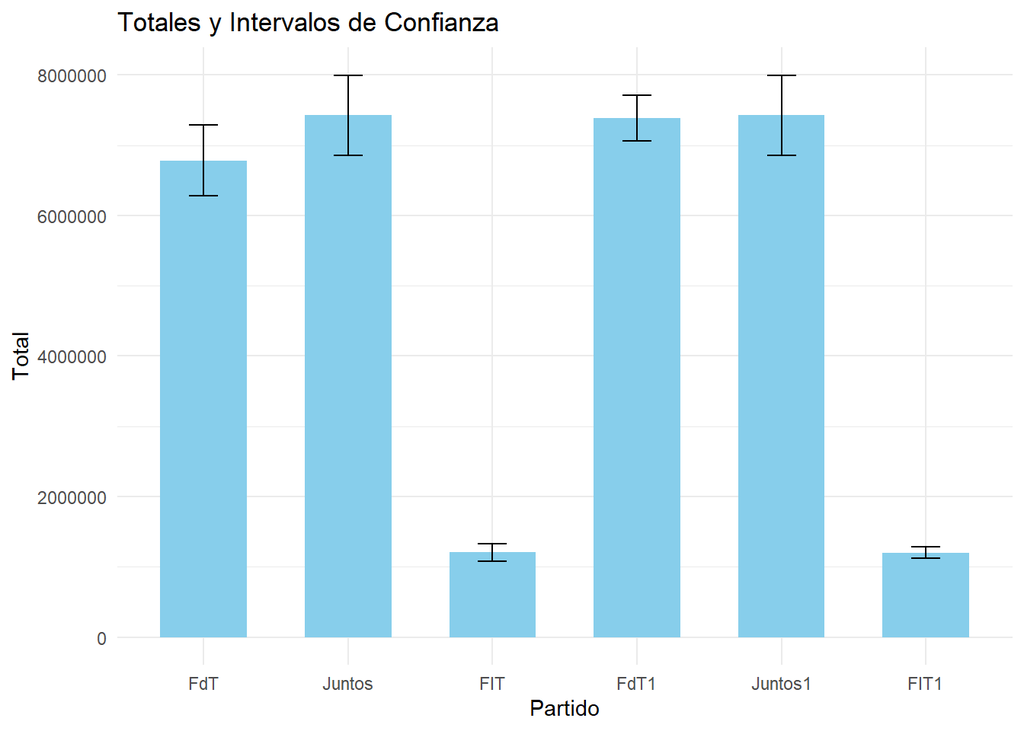

```r
# Crear el gráfico
# Ordenar manualmente los partidos

ggplot(resultados_totales, aes(x = Partido, y = Total)) +
  geom_bar(stat = "identity", fill = "skyblue", width = 0.6) +  # Barras
  geom_errorbar(aes(ymin = `IC Inferior`, ymax = `IC Superior`), width = 0.2) +
  scale_x_discrete(limits = c("FdT", "Juntos", "FIT", "FdT1", "Juntos1", "FIT1")) +
  labs(x = "Partido", y = "Total", title = "Totales y Intervalos de Confianza") +
  theme_minimal()
```

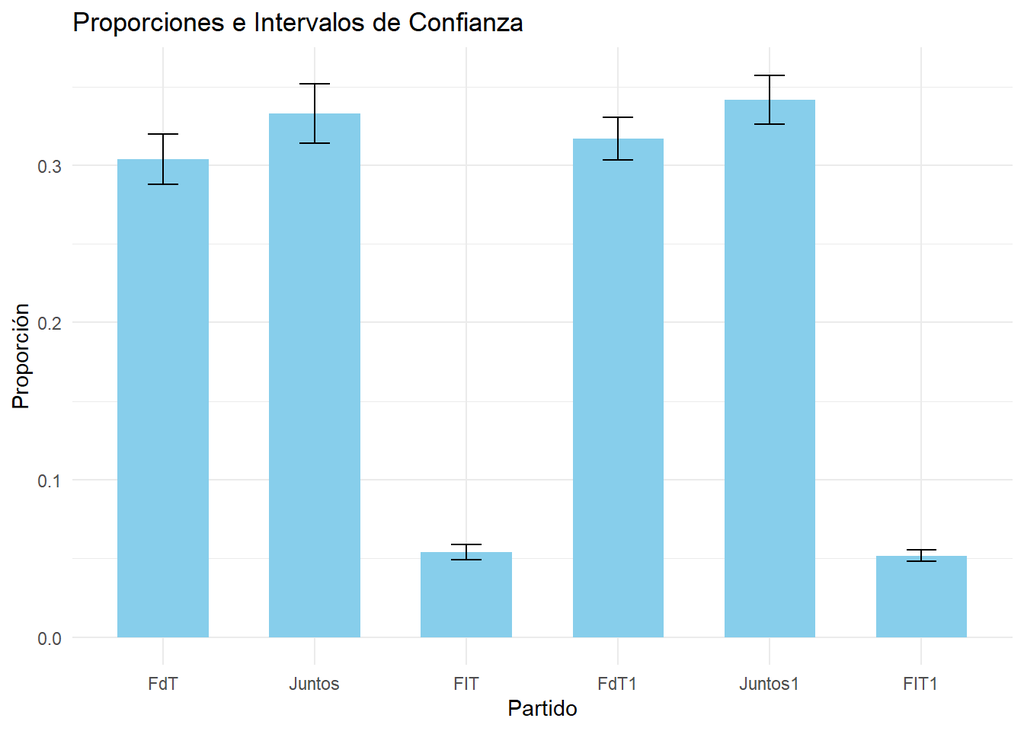

```r
ggplot(df_proporcion, aes(x = Partido, y = Proporción)) +
  geom_bar(stat = "identity", fill = "skyblue", width = 0.6) +  # Barras
  geom_errorbar(aes(ymin = `IC Inferior`, ymax = `IC Superior`), width = 0.2) +
  scale_x_discrete(limits = c("FdT", "Juntos", "FIT", "FdT1", "Juntos1", "FIT1"))+
  labs(x = "Partido", y = "Proporción", title = "Proporciones e Intervalos de Confianza") +
  theme_minimal()
```

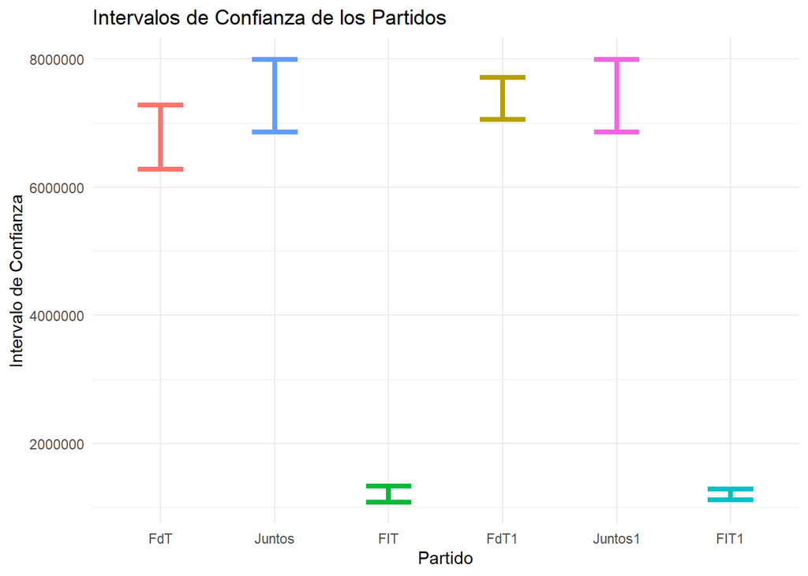

```r
ggplot(resultados_totales, aes(x = Partido, ymin = `IC Inferior`, ymax = `IC Superior`, color = Partido)) +
  geom_errorbar(linewidth = 1.5, width = 0.4) +  # Líneas de error más gruesas
  labs(x = "Partido", y = "Intervalo de Confianza", title = "Intervalos de Confianza de los Partidos") +
  scale_x_discrete(limits = c("FdT", "Juntos", "FIT", "FdT1", "Juntos1", "FIT1"))+
  theme_minimal() +
  theme( #axis.text.x = element_text(angle = 45, hjust = 1),
         legend.position = "none")  # Rotar las etiquetas del eje X si es necesario
```

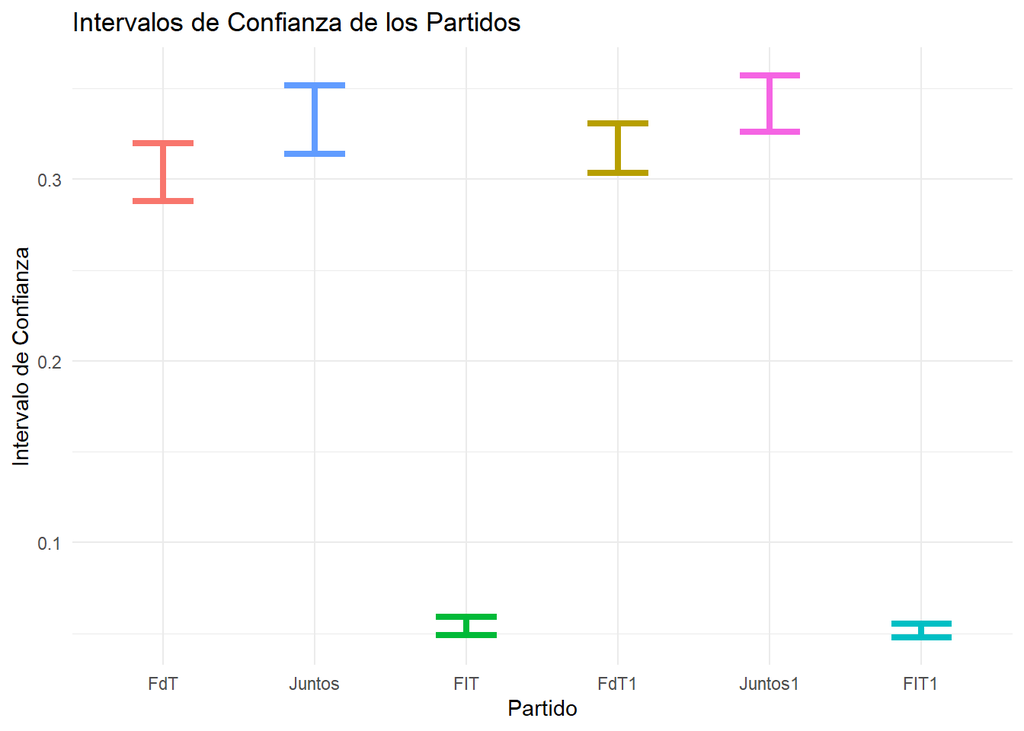

```r
ggplot(df_proporcion, aes(x = Partido, ymin = `IC Inferior`, ymax = `IC Superior`, color = Partido)) +
  geom_errorbar(linewidth = 1.5, width = 0.4) +  # Líneas de error más gruesas
  labs(x = "Partido", y = "Intervalo de Confianza", title = "Intervalos de Confianza de los Partidos") +
  scale_x_discrete(limits = c("FdT", "Juntos", "FIT", "FdT1", "Juntos1", "FIT1")) +
  theme_minimal() +
  theme( #axis.text.x = element_text(angle = 45, hjust = 1),
        legend.position = "none")  # Rotar las etiquetas del eje X si es necesario
```

## 10. Con alguna de las dos estrategias se puede determinar con un 95% de confianza quien sacó más votos?

De igual manera el valor del DEFF en la segunda estrategia es menor demostrando que es una mejor opción para la selección de los casos al reducir la varianza de la estimación.

# Ejercicio 2

```r
#Creación de dataframe
zona<-c("A","B","C")
hogares_marco<-c(25000,65000,20000)
hogares_encuestados<-c(200,150,250)
hogares_pobres_muestra<-c(70,80,22)
poblacion_pobre_encuestada<-c(260,400,60)
poblacion_encuestada<-c(820,700,600)

tabla_datos<-as.data.frame(cbind(zona,hogares_marco,hogares_encuestados,hogares_pobres_muestra,poblacion_pobre_encuestada,poblacion_encuestada))

#str(tabla_datos)

tabla_datos <- tabla_datos %>%
  mutate(across(-1, as.numeric))

print(tabla_datos)
```

```
##   zona hogares_marco hogares_encuestados hogares_pobres_muestra
## 1    A         25000                 200                     70
## 2    B         65000                 150                     80
## 3    C         20000                 250                     22
##   poblacion_pobre_encuestada poblacion_encuestada
## 1                        260                  820
## 2                        400                  700
## 3                         60                  600
```

## 1. Presentar en una tabla o gráfico la proporción de hogares pobres por zona

```r
tabla_datos<-tabla_datos %>%
  mutate(ph_hogares=hogares_pobres_muestra/hogares_encuestados,
         ph_poblacion=poblacion_pobre_encuestada/poblacion_encuestada)

print(tabla_datos[, c("zona", "ph_hogares","ph_poblacion")])
```

```
##   zona ph_hogares ph_poblacion
## 1    A  0.3500000    0.3170732
## 2    B  0.5333333    0.5714286
## 3    C  0.0880000    0.1000000
```

## 2. Hallar el factor de expansión de cada hogar de la muestra y de cada persona encuestada

```r
tabla_datos<-tabla_datos %>%
  mutate(F_hogar=hogares_marco/hogares_encuestados,
         F_persona=hogares_marco/hogares_encuestados)
```

Como todas las personas del hogar son encuestadas, la probabilidad de selección de una persona es igual a la del hogar y por tanto el factor de expansión, que es la inversa de la probabilidad de selección, también lo será.

## 4. Estimar, con la muestra seleccionada, el total de hogares pobres y la proporción de hogares pobres, el CV y deff correspondientes. Dar un IC(90%) para cada estimación.

```r
#Estimación

n=sum(tabla_datos$hogares_encuestados) # en la consigna dice 700, no son 600 hogares?
N=sum(tabla_datos$hogares_marco)

#peso en cada estrato

tabla_datos<-tabla_datos %>%
  mutate(wh=hogares_marco/N)

#peso al cuadrado en cada estrato

tabla_datos<-tabla_datos %>%
  mutate(wh2=(hogares_marco/N)^2)

#s2 en cada estrato
tabla_datos <- tabla_datos %>%
  mutate(sh2= ph_hogares * (1 - ph_hogares))

#varianza en estratos
tabla_datos <- tabla_datos %>%
  mutate(varianza= wh2*sh2/hogares_encuestados)

#varianza del estimador
varianza_estimador=sum(tabla_datos$varianza) * sum(tabla_datos$hogares_marco)^2

#desvío
ds=sqrt(varianza_estimador)

#probabilidad en estrato
tabla_datos <- tabla_datos %>%
  mutate(ph_wh2= ph_hogares * wh)


#estimación del total de hogares pobres
estimacion_total_hogares <-  sum(tabla_datos$ph_wh2 * N)
print(paste("Estimación total hogares pobres: ", round(estimacion_total_hogares)))
```

```
## [1] "Estimación total hogares pobres:  45177"
```

```r
#Intervalos de confianza 90%
IC_infT <- estimacion_total_hogares - 1.64 * ds
IC_supT <- estimacion_total_hogares + 1.64 * ds
print(paste("IC Inferior Total hogares pobres: ", IC_infT))
```

```
## [1] "IC Inferior Total hogares pobres:  40581.8217173449"
```

```r
print(paste("IC Superior Total hogares pobres: ", IC_supT))
```

```
## [1] "IC Superior Total hogares pobres:  49771.5116159885"
```

```r
#estimación de la proporción de hogares pobres
estimacion_proporcion_hogares <-  sum(tabla_datos$ph_wh2 * 100)
print(paste("Estimación proporción hogares pobres: ", estimacion_proporcion_hogares))
```

```
## [1] "Estimación proporción hogares pobres:  41.069696969697"
```

```r
IC_infP <- estimacion_proporcion_hogares/100 - 1.64 * ds/sum(hogares_marco)
IC_supP <- estimacion_proporcion_hogares/100 + 1.64 * ds/sum(hogares_marco)
print(paste("IC Inferior Proporción hogares pobres: ", IC_infP * 100))
```

```
## [1] "IC Inferior Proporción hogares pobres:  36.8925651975862"
```

```r
print(paste("IC Superior Proporción hogares pobres: ", IC_supP * 100))
```

```
## [1] "IC Superior Proporción hogares pobres:  45.2468287418077"
```

```r
#CV

CV_total <- ds / estimacion_total_hogares * 100
print(paste("CV del total: ", CV_total))
```

```
## [1] "CV del total:  6.20172963593941"
```

```r
CV_prop <- (ds/sum(hogares_marco)) / sum(tabla_datos$ph_wh2) * 100
print(paste("CV de la proporción: ", CV_prop))
```

```
## [1] "CV de la proporción:  6.20172963593941"
```

```r
#varianza en MAS (1-n/N)*s2/n (NO ME QUEDA CLARO SI DIVIDO POR n)

p_total_hogares=sum(tabla_datos$hogares_pobres_muestra)/sum(tabla_datos$hogares_encuestados)
s2_total= p_total_hogares * (1 - p_total_hogares)
var_MAS=(1-n/N)*s2_total/n

#DEFF
deff= (ds/sum(hogares_marco))^2/var_MAS
print(paste("DEFF: ", deff))
```

```
## [1] "DEFF:  1.91392781399597"
```

## 5. Por qué, siendo que las tres zonas son diferentes respecto a la variable bajo estudio (proporción de hogares pobres), el deff es claramente mayor a 1 en la estimación del total y proporción de hogares pobres?

Porque la asignación de la cantidad de hogares seleccionado por estrato no se hizo en función de un criterio adecuado, no fue uniforme, ni ponderada ni óptima.De hecho en el estrato donde hay mas hogares en el universo se seleccionan menos hogares en la muestra y viceversa.

## 6. Estimar el total de personas pobres y la proporción de personas pobres (recordar que población pobre es la que habita en hogares pobres). Se puede con los datos disponibles estimar el CV y deff de estas estimaciones?

```r
total_personas_pobres <- sum(tabla_datos$F_persona * tabla_datos$poblacion_pobre_encuestada)
print(paste("Estimación total personas pobres: ", round(total_personas_pobres)))
```

```
## [1] "Estimación total personas pobres:  210633"
```

```r
prop_personas_pobres <- sum(tabla_datos$F_persona * tabla_datos$poblacion_pobre_encuestada) /
                        sum(tabla_datos$F_persona * tabla_datos$poblacion_encuestada)
print(paste("Estimación proporcion personas pobres: ", prop_personas_pobres))
```

```
## [1] "Estimación proporcion personas pobres:  0.464120455380095"
```

No se puede estimar el cv y el DEFF ya que los datos disponibles en el marco muestral refieren a la distribución de hogares por estrato, no conocemos la distribución real de la población pobre entre los estratos para calcular el peso de la población pobre (wh) en el marco muestral, y de esa manera no podemos calcular la varianza del estimador y con ello el CV y el deff que toman este insumo para su cálculo

## 7. En base a los resultados de la encuesta, cómo debería haber sido la distribución de la muestra por zona si el objetivo era estimar el total de hogares pobres en la localidad? (obtener la asignación de Neyman)

```r
#creación de Sh

tabla_datos <- tabla_datos %>%
  mutate(Sh= sqrt(sh2))

#creación de Nh*Sh
tabla_datos <- tabla_datos %>%
  mutate(Nh_Sh= hogares_marco*Sh)

#creación de hogares seleccionados
tabla_datos <- tabla_datos %>%
  mutate(nh_nuevo= round(n*Nh_Sh/sum(Nh_Sh)))

print(tabla_datos[, c("zona", "hogares_marco","nh_nuevo")])
```

```
##   zona hogares_marco nh_nuevo
## 1    A         25000      143
## 2    B         65000      389
## 3    C         20000       68
```

# Ejercicio 3

Seleccionar con sampling una muestra ese diseño y estimar luego con survey la media de Y y el correspondiente CV

```r
data <- data.frame(
  Estrato = c(1, 2, 2, 3, 3, 3, 3, 3),  # Estratos
  Unidad = 1:8,  # Unidades
  Y = c(18, 9, 10, 5, 6, 2, 4, 6)  # Valores de la variable Y
)
```

## Paso 1: Agrego fpc pues selecciono MAS en cada estrato

```r
data <-  data %>%
  group_by(Estrato) %>%
  mutate(fpc=n())
```

## Paso 2: Selección de muestra

```r
# Tamaños de muestra por estrato
n <- c(1, 1, 3)  # Estrato 1: 1 unidad, Estrato 2: 1 unidad, Estrato 3: 3 unidades

# Selección de la muestra estratificada
set.seed(123)  # Para reproducibilidad

#options(survey.lonely.psu="fail")

muestra <- sampling::strata(data = data, stratanames = "Estrato", size = n, method = "srswor")  # Sin reemplazo

# Extraer las unidades seleccionadas
muestra_seleccionada <- getdata(data, muestra)
```

## Paso 3: Diseño de encuesta

La opcion **adjust** utiliza la media total para el cálculo de varianza en el estrato con solo una observación

```r
options(survey.lonely.psu="adjust")

# Crear un diseño estratificado con los pesos correctos

design <- svydesign(
  ids = ~1,  # Las unidades seleccionadas no tienen subgrupos
  strata = ~Estrato,  # Estratos
  data = muestra_seleccionada,
  Prob = ~Prob,  # Pesos: inverso de la probabilidad de selección
  fpc = ~ fpc
)
```

## Paso 4: Cálculo de estimaciones

```r
# Estimar la media de Y
media_Y <- svymean(~Y, design)
print("Media estimada de Y:")
```

```
## [1] "Media estimada de Y:"
```

```r
print(media_Y)
```

```
##     mean     SE
## Y 7.4167 0.5968
```

```r
# Calcular el coeficiente de variación (CV) de la media
cv_Y <- cv(media_Y)
print("Coeficiente de variación (CV) de la media:")
```

```
## [1] "Coeficiente de variación (CV) de la media:"
```

```r
print(cv_Y)
```

```
##            Y
## Y 0.08046172
```

# Ejercicio 4

```r
Deptos2022 <- read_excel("data/tabla_deptos_2022.xlsx")
```

### 1. Estratificación, tamaño de muestra y asignación

Utilizaremos el comando strata.LH del paquete stratification para conseguir la ‘mejor’ estratificación, tamaño de muestra y asignación, indicando un alloc = c(0.5,0.5,0)).

```r
Estratificacion <- strata.LH(
  x = Deptos2022$Y,   # Variable de estratificación
  CV = 0.05,          # CV
  Ls = 4,             # Estratos
  alloc = c(0.5, 0.5, 0),  # Asignación óptima
  algo = "Kozak"
)
```

El comando strata.LH nos da los puntos de corte que definen los estratos y el tamaño de muestra en cada uno.

```r
Estratificacion$bh
```

```
## [1]  33465.0 128840.5 453186.0
```

De esta manera, los estratos quedaron conformados de la siguiente manera: Estrato 1: Y ≤ 33465 Estrato 2: 33465 < Y ≤ 128840.5 Estrato 3: 128840.5 < Y ≤ 453186 Estrato 4: Y > 453186

```r
Estratificacion$nh
```

```
## [1]  4 11 20 13
```

El comando selecciona entonces 4 unidades del Estrato 1, 11 unidades del Estrato 2, 20 unidades del Estrato 3 y 13 unidades del Estrato 4.

### 2. Nh y nh de cada estrato

El nh lo obtuvimos en el ejercicio anterior. Ahora sacaremos el Nh, es decir, el tamaño poblacional de cada estrato. Este valor indica cuántas unidades pertenecen a cada estrato en el marco poblacional. Lo obtienes sumando las unidades dentro de cada estrato una vez los cortes están definidos.

```r
table(cut(Deptos2022$Y, breaks = c(-Inf, Estratificacion$bh, Inf)))
```

```
##
##     (-Inf,3.35e+04] (3.35e+04,1.29e+05] (1.29e+05,4.53e+05]     (4.53e+05, Inf]
##                 271                 162                  78                  16
```

Los resultados son: Nh para el Estrato 1: 271 Nh para el Estrato 2: 162 Nh para el Estrato 3: 78 Nh para el Estrato 4: 16

```r
#Creamos la columna de estrato en Deptos2022
Deptos2022 <- Deptos2022 %>%
 mutate(estrato = cut(
    Y,
    breaks = c(-Inf, Estratificacion$bh, Inf),
    labels = 1:(length(Estratificacion$bh) + 1),
    include.lowest = TRUE
  ))

#Sumamos Nh y nh
resumen <- Deptos2022 %>%
  group_by(estrato) %>%
  summarise(Nh = n()) %>%
  mutate(nh = Estratificacion$nh)

resumen
```

| estrato | Nh | nh |
| --- | --- | --- |
| 1 | 271 | 4 |
| 2 | 162 | 11 |
| 3 | 78 | 20 |
| 4 | 16 | 13 |

### 3. Seleccionamos una muestra con sampling (MAS en cada estrato)

Realizaremos una muestra aleatoria simple sin reemplazo

```r
nh <- c(4, 11, 20, 13)

Deptos2022 <- Deptos2022[order(Deptos2022$estrato), ]

set.seed(1234)
s <- sampling::strata(Deptos2022,
                      stratanames = "estrato",
            size = nh, method = "srswor")

head(s)
```

|  | estrato | ID_unit | Prob | Stratum |
| --- | --- | --- | --- | --- |
| 98 | 1 | 98 | 0.0147601 | 1 |
| 101 | 1 | 101 | 0.0147601 | 1 |
| 111 | 1 | 111 | 0.0147601 | 1 |
| 133 | 1 | 133 | 0.0147601 | 1 |
| 275 | 2 | 275 | 0.0679012 | 2 |
| 285 | 2 | 285 | 0.0679012 | 2 |

```r
# Extrae las unidades seleccionadas
smuestra <- sampling::getdata(Deptos2022, s)

# Verifica la composición de la muestra por estrato
table(smuestra$estrato)
```

```
##
##  1  2  3  4
##  4 11 20 13
```

```r
resumen
```

| estrato | Nh | nh |
| --- | --- | --- |
| 1 | 271 | 4 |
| 2 | 162 | 11 |
| 3 | 78 | 20 |
| 4 | 16 | 13 |

```r
smuestra <- merge(smuestra, resumen, "estrato")
smuestra$fpc = smuestra$Nh
```

### 4. Declarar el diseño de muestreo con survey

```r
diseno <- svydesign(ids = ~1,
                   strata = ~estrato,
                   probs = ~Prob,
                   data = smuestra,
                   fpc = ~fpc)
```

### 5. Estimaremos el total de Y, con el correspondiente CV y deff.

Calculamos primero total de Y con la función de survey

```r
total_Y <- svytotal(~Y, design = diseno, deff = T)
total_Y
```

```
##      total       SE   DEff
## Y 43013745  1635740 0.0267
```

La estimación del total de Y en la población es 43013745 y el desvio estandar 1635740

```r
#Calculamos el CV y el intervalo de confianza
cv(total_Y)
```

```
##           Y
## Y 0.0380283
```

```r
confint(total_Y)
```

```
##      2.5 %   97.5 %
## Y 39807754 46219736
```

```r
sum(Deptos2022$Y) >= confint(total_Y)[1] & sum(Deptos2022$Y) <= confint(total_Y)[2]
```

```
## [1] TRUE
```

El CV es 3.8%, lo cual es menor al 5% definido por diseño para el calculo del tamaño de muestra y cortes optimos de los estratos.

Con un 95% de confianza, el total de Y en la población se encuentra entre 39807754 y 46219736. El intervalo contiene al verdadero valor del parametro.

Finalmente el deff es 0.0267, por lo que el diseño resulta mas eficiente que seleccionar un MAS sobre todo el marco sin estratificar.